# CTREE Workshop Activity: Replicating (some of) the Harrison and Rubinfeld results

Aaron Swoboda

This activity is based on a series of labs I developed for an undergraduate research seminar on topics in housing economics at Carleton College. After reading “Hedonic housing prices and the demand for clean air” (Harrison and Rubinfeld 1978), students are asked to replicate some of the main results from the paper as well as two subsequent corrections applied by Gilley and Pace (1996).

In this activity we will see how R Markdown can be used to:

1. manage references (inline citations and references cited list creation)
2. include external images
3. create hyperlinks
4. produce nicely formatted tables from R output
5. generate hyperlinked footnotes
6. include inline R code
7. produce both .html and .pdf output documents

## Some Basic Results from Harrison and Rubinfeld (1978)

Below are images of two tables of results from the Harrison and Rubinfeld (1978) paper:

- The summary statistics from Table V, and
- The “basic equation” OLS regression results from Table VII:

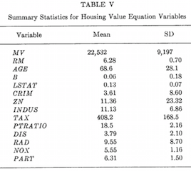

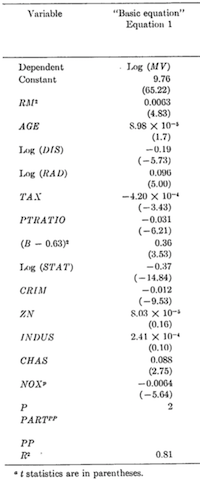

## Accessing the Data

The dataset consisting of 14 variables across 506 census tracts is available in at least three different ways.

1. Belsley, Kuh, and Welsch (1980) (a book)
2. The [UCI Machine Learning Repository](http://archive.ics.uci.edu/ml/datasets/Housing)
3. Within the Statistical Software R

For this exercise we will access the `Boston` dataset in the [`MASS` package](https://cran.r-project.org/web/packages/MASS/MASS.pdf).

```r
library(MASS)
data("Boston")
str(Boston)
```

```
## 'data.frame':    506 obs. of  14 variables:
##  $ crim   : num  0.00632 0.02731 0.02729 0.03237 0.06905 ...
##  $ zn     : num  18 0 0 0 0 0 12.5 12.5 12.5 12.5 ...
##  $ indus  : num  2.31 7.07 7.07 2.18 2.18 2.18 7.87 7.87 7.87 7.87 ...
##  $ chas   : int  0 0 0 0 0 0 0 0 0 0 ...
##  $ nox    : num  0.538 0.469 0.469 0.458 0.458 0.458 0.524 0.524 0.524 0.524 ...
##  $ rm     : num  6.58 6.42 7.18 7 7.15 ...
##  $ age    : num  65.2 78.9 61.1 45.8 54.2 58.7 66.6 96.1 100 85.9 ...
##  $ dis    : num  4.09 4.97 4.97 6.06 6.06 ...
##  $ rad    : int  1 2 2 3 3 3 5 5 5 5 ...
##  $ tax    : num  296 242 242 222 222 222 311 311 311 311 ...
##  $ ptratio: num  15.3 17.8 17.8 18.7 18.7 18.7 15.2 15.2 15.2 15.2 ...
##  $ black  : num  397 397 393 395 397 ...
##  $ lstat  : num  4.98 9.14 4.03 2.94 5.33 ...
##  $ medv   : num  24 21.6 34.7 33.4 36.2 28.7 22.9 27.1 16.5 18.9 ...
```

## Replicating the Harrison and Rubinfeld (1978) Results

Let’s use the `stargazer` command from the `stargazer` package to calculate and present the summary statistics for the dataset.

```r
library(stargazer)
stargazer(Boston, type = "text")
```

```
##
## =============================================
## Statistic  N   Mean   St. Dev.  Min     Max
## ---------------------------------------------
## crim      506  3.614   8.602   0.006  88.976
## zn        506 11.364   23.322  0.000  100.000
## indus     506 11.137   6.860   0.460  27.740
## chas      506  0.069   0.254     0       1
## nox       506  0.555   0.116   0.385   0.871
## rm        506  6.285   0.703   3.561   8.780
## age       506 68.575   28.149  2.900  100.000
## dis       506  3.795   2.106   1.130  12.127
## rad       506  9.549   8.707     1      24
## tax       506 408.237 168.537   187     711
## ptratio   506 18.456   2.165   12.600 22.000
## black     506 356.674  91.295  0.320  396.900
## lstat     506 12.653   7.141   1.730  37.970
## medv      506 22.533   9.197   5.000  50.000
## ---------------------------------------------
```

A comparison of Table V and the results above shows that some of the variables are not in the approporiate units to replicate the summary statistics. Let’s using the `dlpyr` package to create a modified dataset with renamed and appropriately rescaled values.

```r
library(dplyr)
# copy the data frame
boston.df.1978 = Boston
# change the names to uppercase for consistency with H&R (1978)
names(boston.df.1978) = toupper(names(boston.df.1978))

# now rescale and reorder for consistency
boston.df.1978 = boston.df.1978 %>%
  # rescale
  mutate(MV = MEDV*1000,
         Btransformed = BLACK/1000,
         LSTAT = LSTAT/100,
         NOX = NOX*10) %>%
  # and reorder
  select(MV, RM, AGE, Btransformed, LSTAT, CRIM, ZN,
         INDUS, TAX, PTRATIO, DIS, RAD, NOX, CHAS)

stargazer(boston.df.1978,
          type = "text",
          digits = 2)
```

```
##
## =================================================
## Statistic     N    Mean    St. Dev.  Min    Max
## -------------------------------------------------
## MV           506 22,532.81 9,197.10 5,000  50,000
## RM           506   6.28      0.70    3.56   8.78
## AGE          506   68.57    28.15    2.90  100.00
## Btransformed 506   0.36      0.09   0.0003  0.40
## LSTAT        506   0.13      0.07    0.02   0.38
## CRIM         506   3.61      8.60    0.01  88.98
## ZN           506   11.36    23.32    0.00  100.00
## INDUS        506   11.14     6.86    0.46  27.74
## TAX          506  408.24    168.54   187    711
## PTRATIO      506   18.46     2.16   12.60  22.00
## DIS          506   3.80      2.11    1.13  12.13
## RAD          506   9.55      8.71     1      24
## NOX          506   5.55      1.16    3.85   8.71
## CHAS         506   0.07      0.25     0      1
## -------------------------------------------------
```

That’s better.[^1] Now let’s estimate the OLS equation shown above. The `stargazer` command can also be used to produce a table of regression output.

```r
HR.lm = lm(log(MV) ~ I(RM^2) + AGE + log(DIS) +
                      log(RAD) + TAX + PTRATIO + Btransformed +
                      log(LSTAT) + CRIM + ZN + INDUS + CHAS +
                      I(NOX^2),
                    data = boston.df.1978)
stargazer(HR.lm, type = "text")
```

```
##
## ===============================================
##                         Dependent variable:
##                     ---------------------------
##                               log(MV)
## -----------------------------------------------
## I(RM2)                       0.006***
##                               (0.001)
##
## AGE                           0.0001
##                               (0.001)
##
## log(DIS)                     -0.191***
##                               (0.033)
##
## log(RAD)                     0.096***
##                               (0.019)
##
## TAX                         -0.0004***
##                              (0.0001)
##
## PTRATIO                      -0.031***
##                               (0.005)
##
## Btransformed                 0.364***
##                               (0.103)
##
## log(LSTAT)                   -0.371***
##                               (0.025)
##
## CRIM                         -0.012***
##                               (0.001)
##
## ZN                            0.0001
##                               (0.001)
##
## INDUS                         0.0002
##                               (0.002)
##
## CHAS                         0.091***
##                               (0.033)
##
## I(NOX2)                      -0.006***
##                               (0.001)
##
## Constant                     9.756***
##                               (0.150)
##
## -----------------------------------------------
## Observations                    506
## R2                             0.806
## Adjusted R2                    0.801
## Residual Std. Error      0.182 (df = 492)
## F Statistic          157.128*** (df = 13; 492)
## ===============================================
## Note:               *p<0.1; **p<0.05; ***p<0.01
```

Tweaking a few settings[^2] to customize our table shows just how similar our results are to the reported values.

```r
stargazer(HR.lm, type = "text",
          intercept.bottom = FALSE,
          keep.stat = "rsq",
          omit.table.layout = "n",
          report = "vct",
          digits = 5,
          no.space = TRUE)
```

```
##
## ================================
##              Dependent variable:
##              -------------------
##                    log(MV)
## --------------------------------
## Constant           9.75629
##                 t = 65.22075
## I(RM2)             0.00633
##                  t = 4.82256
## AGE                0.00009
##                  t = 0.17242
## log(DIS)          -0.19126
##                 t = -5.72750
## log(RAD)           0.09571
##                  t = 5.00207
## TAX               -0.00042
##                 t = -3.42613
## PTRATIO           -0.03112
##                 t = -6.20808
## Btransformed       0.36370
##                  t = 3.52708
## log(LSTAT)        -0.37116
##                 t = -14.84063
## CRIM              -0.01186
##                 t = -9.53205
## ZN                 0.00008
##                  t = 0.15853
## INDUS              0.00024
##                  t = 0.10134
## CHAS               0.09140
##                  t = 2.75268
## I(NOX2)           -0.00638
##                 t = -5.63930
## --------------------------------
## R2                 0.80589
## ================================
```

## Data Problems

Nearly 20 years after the Harrison and Rubinfeld (1978) article, Gilley and Pace (1996) revealed that the underlying data used in the original analysis had two significant problems.

- There were data entry mistakes (eight dependent values appeared to have been entered incorrectly)
- Some dependent variable values were censored (census tracts with median home values above $50,000 were simply recorded as $50,000)

Two tables from Gilley and Pace (1996) are shown below. TABLE I shows the data entry errors[^3], while Table III presents three sets of regression results: the uncorrected OLS results, the Corrected OLS results, and a Tobit model.

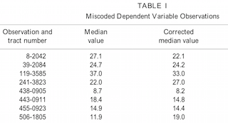

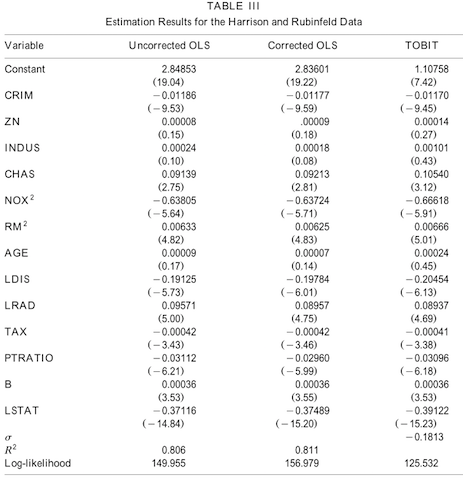

### Replicating the Gilley and Pace (1996) Uncorrected OLS Results

Inspection of the first column of results shows nearly identical values from our earlier regression. However, Gilley and Pace (1996) reports a constant term of 2.84853, whereas Harrison and Rubinfeld (1978) report a constant of 9.7562879. Why the difference?

The answer is scaling (again!). Notably, Gilley and Pace (1996) present the median house value variable in $1,000s (i.e. 27.1 instead of $27,100). Let’s rescale the dependent variable (and two others) and rerun the regression.

```r
GP.lm.Uncorrected = lm(log(MV/1000) ~  CRIM + ZN + INDUS + CHAS +
                     I(NOX^2/100) + I(RM^2) + AGE +
                     log(DIS) + log(RAD) + TAX + PTRATIO +
                     I(Btransformed*1000) + log(LSTAT),
                     data = boston.df.1978)
```

### Replicating the Gilley and Pace (1996) Corrected OLS Results

Let’s create a new variable, `CMV` for the corrected median values and see if we can replicate the other two columns from Table 3.

```r
obs.incorrect = c(8, 39, 191, 241, 438, 443, 455, 506) # note 191 instead of 119
correct.values = c(22.1, 24.2, 33, 27, 8.2, 14.8, 14.4, 19)

boston.df.1978 = boston.df.1978 %>%
  mutate(CMV = MV/1000)
boston.df.1978$CMV[obs.incorrect] = correct.values
```

We now should be able to replicate the results from Column 2 in Table III simply by re-estimating the regression from column 1 but using `CMV` as the dependent variable.

```r
GP.lm.Corrected = lm(log(CMV) ~ CRIM + ZN + INDUS +
                       CHAS + I(NOX^2/100) + I(RM^2) + AGE +
                       log(DIS) + log(RAD) + TAX + PTRATIO +
                       I(Btransformed*1000) + log(LSTAT),
                     data = boston.df.1978)
```

### Replicating the Gilley and Pace (1996) Corrected Tobit Results

Let’s just go ahead and estimate the Tobit model as well and present all three regressions in one table using `stargazer`.

```r
library(AER)
GP.lm.Tobit = tobit(log(CMV) ~  CRIM + ZN + INDUS +
                      CHAS + I(NOX^2/100) + I(RM^2) +
                      AGE + log(DIS) + log(RAD) + TAX + PTRATIO +
                      I(Btransformed*1000) + log(LSTAT),
                    right = log(50),
                    data = boston.df.1978)
```

```r
stargazer(GP.lm.Uncorrected, GP.lm.Corrected, GP.lm.Tobit,
          type = "text", digits = 5,
          intercept.bottom = FALSE,
          keep.stat = "rsq",
          omit.table.layout = "n",
          report = "vct",
          no.space = TRUE)
```

```
##
## ================================================================
##                                   Dependent variable:
##                        -----------------------------------------
##                        log(MV/1000)           log(CMV)
##                             OLS           OLS          Tobit
##                             (1)           (2)           (3)
## ----------------------------------------------------------------
## Constant                  2.84853       2.83601       2.80445
##                        t = 19.04243  t = 19.22372  t = 18.79884
## CRIM                     -0.01186      -0.01177      -0.01170
##                        t = -9.53205  t = -9.59008  t = -9.44951
## ZN                        0.00008       0.00009       0.00014
##                         t = 0.15853   t = 0.18401   t = 0.27166
## INDUS                     0.00024       0.00018       0.00101
##                         t = 0.10134   t = 0.07676   t = 0.42624
## CHAS                      0.09140       0.09213       0.10541
##                         t = 2.75268   t = 2.81347   t = 3.12409
## I(NOX2/100)              -0.63805      -0.63724      -0.66621
##                        t = -5.63930  t = -5.71086  t = -5.91071
## I(RM2)                    0.00633       0.00626       0.00666
##                         t = 4.82256   t = 4.83322   t = 5.01024
## AGE                       0.00009       0.00007       0.00024
##                         t = 0.17242   t = 0.13679   t = 0.45037
## log(DIS)                 -0.19126      -0.19784      -0.20455
##                        t = -5.72750  t = -6.00743  t = -6.13354
## log(RAD)                  0.09571       0.08957       0.08937
##                         t = 5.00207   t = 4.74638   t = 4.68565
## TAX                      -0.00042      -0.00042      -0.00041
##                        t = -3.42613  t = -3.46406  t = -3.37752
## PTRATIO                  -0.03112      -0.02960      -0.03096
##                        t = -6.20808  t = -5.98646  t = -6.17677
## I(Btransformed * 1000)    0.00036       0.00036       0.00036
##                         t = 3.52708   t = 3.55082   t = 3.53534
## log(LSTAT)               -0.37116      -0.37489      -0.39123
##                        t = -14.84063 t = -15.19961 t = -15.23336
## ----------------------------------------------------------------
## R2                        0.80589       0.81076
## ================================================================
```

### Now you try

1. Add another image of the Gilley and Pace (1996) regression output table near our final replication table to make regression output easier to compare.
2. Change the necessary code to “correct” the observation presented in Gilley and Pace (1996) (observation 119 rather than observation 191). Observe that we now obtain different results in our final table of regression output.
3. Use inline code to show the reader the median house value for observation 119.
4. Add the `stargazer` package to our references (you will need to look up the citation key in the `ReplicationBib.bib` file).
5. Change the output produced by this document from `html_notebook` to `pdf_document`
6. Produce a fancy `Latex` final table of regression results (now that you are generating a .pdf file). You will need to change the `type = "text"` option in the `stargazer` command to `type = "latex"` and also update `results = "markdown"` in the chunk option to be `results = "asis"`.

### References

Belsley, David A., Edwin Kuh, and Roy E. Welsch. 1980. *Regression Diagnostics: Identifying Influential Data and Sources of Collinearity*. John Wiley & Sons.

Gilley, Otis, and R. Kelley Pace. 1996. “On the Harrison and Rubinfeld Data.” *Journal of Environmental Economics and Management* 31 (3): 403–5. doi:10.1006/jeem.1996.0052.

Harrison, D, and D Rubinfeld. 1978. “Hedonic housing prices and the demand for clean air.” *Journal of Environmental Economics and Management* 5 (1): 81–102.

[^1]: The original “Black” variable cannot be recovered from the these data, which have been transformed using the equation $(Black - 0.63)^2$.
[^2]: Check out this cheatsheet for the `stargazer` package: http://jakeruss.com/cheatsheets/stargazer.html
[^3]: One of my students pointed out that there is a typo in the Gilley and Pace (1996) TABLE I. They believe observation 191 (rather than 119) should have a corrected median value of 33.0 (from an incorrect value of 37.0). The results shown in Gilley and Pace (1996) can be replicated when observation 191 is corrected but not when observation 119 is “corrected.”